# Machine Learning Basics: praktijkdeel

Deze notebook bevat het praktijkdeel van het examen Machine Learning Basics. Volg de onderstaande instructies om de opdracht uit te voeren. Je hebt de resterende tijd van de 3 uur voor het examen om deze opdracht te voltooien. Let goed op! Je dient de vraag te beantwoorden met code en/of tekst en/of visualisaties, afhankelijk van wat er gevraagd wordt doorheen de notebook. De indiening van het eindresultaat gebeurt via de cloudtoepassing. Je dient zowel deze notebook als een HTML-export van deze notebook in te dienen. Zorg ervoor dat je naam duidelijk zichtbaar zijn in beide bestanden en dat de output van alle codecellen zichtbaar is in de HTML-export.

Succes!

## Fizzy Business: How Machine Learning Helps Predict Soda Types

Understanding the chemical composition of beverages is crucial for quality control and product development in the beverage industry. Measuring properties such as sugar content, caffeine level, acidity, and carbonation helps manufacturers ensure consistent taste and quality. However, comprehensive testing of all properties can be time-consuming and costly, making it valuable to predict certain characteristics from others.

Beverage companies are constantly working to optimize their formulations and understand the relationships between different chemical properties. One important aspect is understanding how various measurable properties relate to each other, which can help in quality control and new product development.

A major beverage company reached out to you as a machine learning expert for assistance in understanding their soda properties. They've provided you with a dataset called `soda_properties.csv`, which contains various chemical and physical measurements of different soda samples.

The dataset includes multiple numeric features representing different properties of the soda samples:

- **sugar_content**: Sugar content level
- **caffeine_content**: Caffeine content level
- **acidity_level**: Acidity level
- **carbonation_level**: Carbonation level
- **soda_type**: Type of soda drink (target variable)

In this project, you will explore the dataset and build machine learning models to predict the type of soda based on its chemical properties to investigate the relationships between the properties and the soda types.

```python
import pandas as pd

# Load the dataset - VUL AAN
sodas = pd.read_csv("soda_properties.csv")

sodas.info()
```

```
<class 'pandas.core.frame.DataFrame'>
RangeIndex: 2200 entries, 0 to 2199
Data columns (total 5 columns):
 #   Column             Non-Null Count  Dtype
---  ------             --------------  -----
 0   sugar_content      2200 non-null   int64
 1   caffeine_content   2200 non-null   int64
 2   acidity_level      2200 non-null   int64
 3   carbonation_level  2200 non-null   float64
 4   soda_type          2200 non-null   object
dtypes: float64(1), int64(3), object(1)
memory usage: 86.1+ KB
```

```python
# to have an idea of the data itself, random sample:
sodas.sample(7).T
```

|  | 1853 | 1198 | 1010 | 1529 | 1485 | 1149 | 2124 |
| --- | --- | --- | --- | --- | --- | --- | --- |
| sugar_content | 24 | 31 | 118 | 6 | 111 | 5 | 108 |
| caffeine_content | 27 | 20 | 88 | 144 | 5 | 19 | 33 |
| acidity_level | 34 | 30 | 52 | 198 | 50 | 25 | 31 |
| carbonation_level | 6.203377 | 6.207496 | 5.843163 | 5.559364 | 6.399891 | 6.441328 | 7.393826 |
| soda_type | Energy_Drink | Lemon_Lime | Ginger_Ale | Club_Soda | Diet_Pepsi | Lemon_Lime | Lemonade |

```python
# Check for missing values - VUL AAN
print(f"Missing values check:\n{sodas.isna().sum()}")

# Check how many soda types we have, i.e., multi-class target - VUL AAN
print(f"{sodas["soda_type"].size} types of soda:\n{sodas["soda_type"].unique()}")
```

[output not shown]

```python
#####################
# VRAAG: Exploreer de dataset. Welke kolommen bevatten mogelijk nuttige informatie om het type soda te voorspellen?
# Welke kolommen lijken minder relevant? Leg uit waarom je dat vindt.
#####################
sodas.describe()
```

|  | sugar_content | caffeine_content | acidity_level | carbonation_level |
| --- | --- | --- | --- | --- |
| count | 2200.000000 | 2200.000000 | 2200.000000 | 2200.000000 |
| mean | 50.551818 | 53.362727 | 48.149091 | 6.469480 |
| std | 36.917334 | 32.985883 | 50.647931 | 0.773938 |
| min | 0.000000 | 5.000000 | 5.000000 | 3.504752 |
| 25% | 21.000000 | 28.000000 | 20.000000 | 5.971693 |
| 50% | 37.000000 | 51.000000 | 32.000000 | 6.425045 |
| 75% | 84.250000 | 68.000000 | 49.000000 | 6.923643 |
| max | 140.000000 | 145.000000 | 205.000000 | 9.935091 |

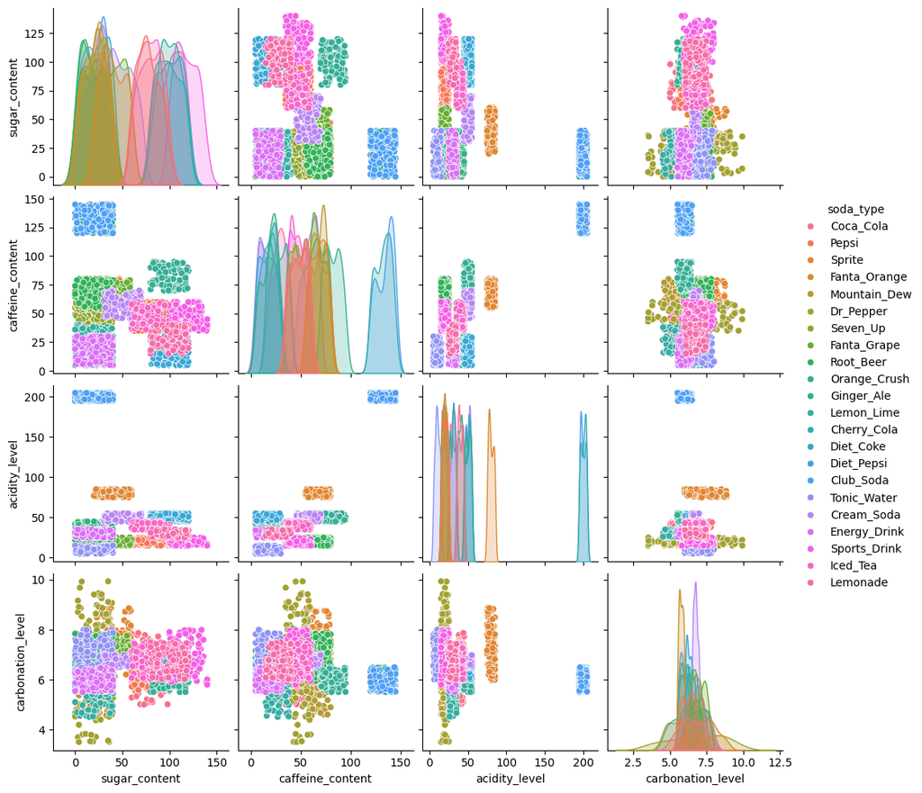

```python
import seaborn as sns
import matplotlib.pyplot as plt

sns.pairplot(sodas, vars=sodas.columns[:-1], hue="soda_type")
```

As per above, acidity level and possibly caffeine content seem to provide the most clear destinction for the soda types. To confirm that it would be best to compute a correlation matrix and visualize it as a heatmap, but it does not go with unencoded stings as target, so drop those first.

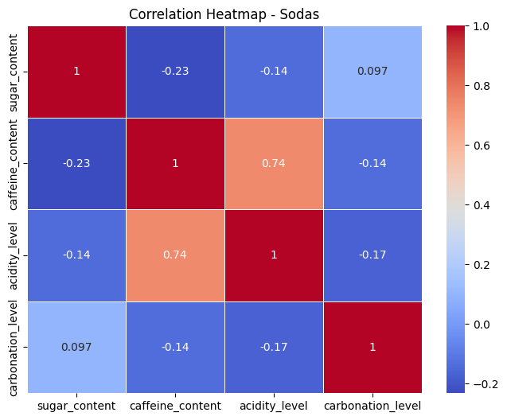

```python
# Compute correlation matrix
corr_matrix = sodas.drop(columns=['soda_type']).corr()
# Plot heatmap
plt.figure(figsize=(8,6))
sns.heatmap(corr_matrix, annot=True, cmap='coolwarm', linewidths=0.5)
plt.title("Correlation Heatmap - Sodas")
plt.show()
```

Now the strong positive correlation is evident, plot it on a scatter

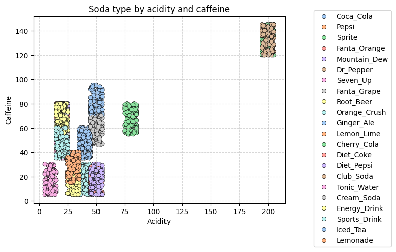

```python
plt.figure()
sns.scatterplot(
    data=sodas,
    x='acidity_level',
    y='caffeine_content',
    hue='soda_type',
    palette='pastel',
    edgecolor='black'
)
plt.title("Soda type by acidity and caffeine")
plt.xlabel("Acidity")
plt.ylabel("Caffeine")
plt.legend(title="Soda type")
plt.grid(True, linestyle='--', alpha=0.5)
plt.legend(bbox_to_anchor=(1.1, 1.05))
plt.show()
```

Om de predictieve sterkte van de verschillende eigenschappen te onderzoeken, maken we een model dat het type frisdrank voorspelt op basis van 1 enkele eigenschap. We herhalen dit voor alle eigenschappen en vergelijken de resultaten van de f1-score.

```python
# All required libraries are imported here for you.
from sklearn.linear_model import LogisticRegression
from sklearn.model_selection import train_test_split
from sklearn import metrics

# Split into feature and target sets - VUL AAN
X = sodas.iloc[:, :-1]
y = sodas["soda_type"]

# Split the data into training and testing sets - VUL AAN
X_train, X_test, y_train, y_test = train_test_split(
    X,
    y,
    test_size=0.2,
    random_state=42,
    stratify=y,
)
```

```python
############
# VRAAG: hieronder is F1 score berekend bij het gebruik van de variabele 'sugar_content'.
# Wat zijn de f1 scores voor elk van de andere modellen (bij het gebruik van de andere variabelen apart)?
# Maak een for-loop die dit automatisch doet.
###########
import numpy as np

# Create a dictionary to store the model performance for each feature
feature_performance = {}
feature_names = ['sugar_content', 'caffeine_content', 'acidity_level', 'carbonation_level']

# Train a logistic regression model for each feature
log_reg = LogisticRegression(random_state=42, max_iter=100) # multi_class="multinomial"

for col in feature_names:
    col_train = np.reshape(X_train[col], (-1,1))
    col_test = np.reshape(X_test[col], (-1, 1))
    y_train = np.reshape(y_train, (-1, 1))
    log_reg.fit(col_train, y_train)
    y_pred = log_reg.predict(col_test)

    # Calculate F1 score, the harmonic mean of precision and recall
    # Zorg dat je het gewogen gemiddelde neemt van de f1 score owv de multi-class classification! - VUL AAN!
    f1 = metrics.f1_score(y_test, y_pred, average="weighted")

    # Add feature-f1 score pairs to the dictionary
    feature_performance[col] = f1
    print(f"F1-score for {col}: {f1}")
```

```
F1-score for sugar_content: 0.10344617990869984
F1-score for caffeine_content: 0.13677680017303795
```

```
F1-score for acidity_level: 0.24688826059988472
F1-score for carbonation_level: 0.08880058283835049
```

```python
# Find the best performing feature
best_feature_name = max(feature_performance, key=feature_performance.get)
best_predictive_feature = {best_feature_name: feature_performance[best_feature_name]}
best_predictive_feature
```

```
{'acidity_level': 0.24688826059988472}
```

```python
# DUS: Wat zijn de f1 scores voor elk van de andere modellen (bij het gebruik van de andere variabelen apart)?
# Welke variabele op zijn alleen is het beste in het voorspellen van het type soda?

"""
Scores van log reg op afzonderlijke features op een rij:

F1-score for sugar_content: 0.10344617990869984
F1-score for caffeine_content: 0.13677680017303795
F1-score for acidity_level: 0.24688826059988472
F1-score for carbonation_level: 0.08880058283835049

DUS: acidity_level is the best om de type te voorspelen, dan caffeine_content (wat we al uit de EDA wisten)
"""
```

```
'\nScores van log reg op afzonderlijke features op een rij:\n\nF1-score for sugar_content: 0.10344617990869984\nF1-score for caffeine_content: 0.13677680017303795\nF1-score for acidity_level: 0.24688826059988472\nF1-score for carbonation_level: 0.08880058283835049\n'
```

Nu bouwen we een logistische regressie model dat alle eigenschappen samen gebruikt en bekijken we en vergelijken de modelprestaties met de modellen voor elke eigenschap afzonderlijk.

```python
from sklearn.linear_model import LogisticRegression
from sklearn.metrics import classification_report, confusion_matrix

# Train logistic regression with all features
logreg = LogisticRegression(random_state=42, max_iter=100)
logreg.fit(X_train, y_train)

# Make predictions on the test set - VUL AAN
y_pred = logreg.predict(X_test)

# Evaluate the model - VUL AAN
f1 = metrics.f1_score(y_test, y_pred, average="weighted")
print(f"\nF1-score with all features: {f1}")
```

```
F1-score with all features: 0.5443384263700046
```

```python
##############
# VRAAG: Vergelijk de f1 score van het model met alle features met die van de beste enkele feature. Wat zie je? Wat wil dit zeggen?
##############
"""
F1-score with all features meegenomen is significant hoger dan de log res met de meest relevante feature:
F1-score for acidity_level: 0.24688826059988472
F1-score with all features: 0.5443384263700046
"""
print(f"Improvement in F1-score in comparison with the best feature: {f1 - feature_performance[best_feature_name]}")
```

```
Improvement in F1-score in comparison with the best feature: 0.2974501657701199
```

Nu maken we ons model opnieuw maar deze keer zorgen we ervoor dat onze data gestandaardiseerd is. We vergelijken de resultaten met het vorige model dat alle eigenschappen gebruikte zonder standaardisatie. Is het model verbeterd door standaardisatie? Waarom wel of niet?

```python
from sklearn.preprocessing import StandardScaler

# Scale the features
scaler = StandardScaler()
X_train_scaled = scaler.fit_transform(X_train)
X_test_scaled = scaler.transform(X_test)

# Train with scaled data
logreg_scaled = LogisticRegression(random_state=42, max_iter=1000)
logreg_scaled.fit(X_train_scaled, y_train)

# Make NEW predictions with the scaled model - THIS WAS MISSING!
y_pred_scaled = logreg_scaled.predict(X_test_scaled)

# Check coefficients (now meaningful for comparison)
print("Scaled Model Coefficients:")
for feature, coef in zip(feature_names, logreg_scaled.coef_[0]):
    print(f"{feature}: {coef:.4f}")

# Evaluate the SCALED model with its predictions
f1_scaled = metrics.f1_score(y_test, y_pred_scaled, average="weighted")
print(f"\nF1-score with scaled features: {f1_scaled}")
```

```
Scaled Model Coefficients:
sugar_content: -0.7711
caffeine_content: 3.2035
acidity_level: 5.4474
carbonation_level: -0.2510

F1-score with scaled features: 0.6352283914347523
```

## **Multiclass Logistic Regression Interpretation:**

```python
# You're only seeing coefficients for the first class
print("First class:", logreg_scaled.classes_[0])
print("Coefficients for first class:", logreg_scaled.coef_[0])
```

```
First class: Cherry_Cola
Coefficients for first class: [-0.77105287  3.20350214  5.44739071 -0.25097568]
```

## **Correct Interpretation:**

The coefficients you see are **specific to predicting the first soda type** (likely 'Cherry_Cola' or whatever is first alphabetically) **vs all other types**.

## **To Get the Full Picture:**

```python
# See all coefficients for all classes
for i, soda_type in enumerate(logreg_scaled.classes_):
    print(f"\nCoefficients for {soda_type}:")
    for feature, coef in zip(feature_names, logreg_scaled.coef_[i]):
        print(f"  {feature}: {coef:.4f}")
```

```
Coefficients for Cherry_Cola:
  sugar_content: -0.7711
  caffeine_content: 3.2035
  acidity_level: 5.4474
  carbonation_level: -0.2510

Coefficients for Club_Soda:
  sugar_content: -1.2435
  caffeine_content: 3.9895
  acidity_level: 4.6153
  carbonation_level: -1.2813

Coefficients for Coca_Cola:
  sugar_content: 2.0473
  caffeine_content: 0.1011
  acidity_level: 1.3374
  carbonation_level: -0.2648

Coefficients for Cream_Soda:
  sugar_content: -0.3493
  caffeine_content: 1.4946
  acidity_level: 2.4860
  carbonation_level: 0.3207

Coefficients for Diet_Coke:
  sugar_content: 3.3584
  caffeine_content: -5.0664
  acidity_level: 3.9670
  carbonation_level: 0.2178

Coefficients for Diet_Pepsi:
  sugar_content: 3.3277
  caffeine_content: -4.9655
  acidity_level: 3.6331
  carbonation_level: -0.8145

Coefficients for Dr_Pepper:
  sugar_content: -2.6478
  caffeine_content: -0.1139
  acidity_level: -2.7011
```

[output cut: 76 more lines]

```
  caffeine_content: 1.0455
  acidity_level: -4.7550
  carbonation_level: 0.9763

Coefficients for Sprite:
  sugar_content: -1.3815
  caffeine_content: 0.7438
  acidity_level: 5.2206
  carbonation_level: 1.1683

Coefficients for Tonic_Water:
  sugar_content: -2.0852
  caffeine_content: -5.2756
  acidity_level: -6.1947
  carbonation_level: 0.7151
```

```python
###############
# VRAAG: Leg uit wat de modelcoëfficiënten betekenen in het geval van het soda_type 'Coca_Cola'.
###############
```

**Coefficients for Coca_Cola:**

- sugar_content: 2.0473
- caffeine_content: 0.1011
- acidity_level: 1.3374
- carbonation_level: -0.2648

In logistic regression the coefficient is the expected change in log-odds of having the outcome per unit change in data. In this particular case it means the proportion by which the increase in sugar_content, caffeine_content, or acidity_level or decrease in carbonation_level increases the odds of soda being of type "Coca_Cola".